# Вычисления по формуле

```python
import numpy
import scipy.special
import scipy.misc
import ipyvolume as ipv
import npy2cube
from IPython.display import display
```

Самая удобная запись решения для волновой функции водорода в сферических координатах. Формула имеет следующий вид:

$\psi_{nlm}(r,\theta, \varphi) = \sqrt{\frac{(n-l-1)!}{2n(n+l)!}}* (\frac{2}{na_0})^\frac{3}{2} * exp(-\frac{r}{na_0}) * (\frac{2r}{na_0})^l * L_{n-l-1}^{2l+1}(\frac{2r}{na_0})*Y_{l,m}(\theta,\varphi)$

Здесь n, l, m - квантовые числа. n = {1,2..}, l = {0,1,..,n-1}, m = {-l,..,l};

$a_0$ - приведенный радиус Бора;

$L_{n-l-1}^{2l+1}$ - обощенные многочлены Лагранжа степени (n-l-1);

$Y_{l,m}(\theta,\varphi)$ - сферическая гармоническая функция степени ℓ и порядка m.

Реализуем функцию для вычисления атомных орбиталей водорода. У нас есть точки [x,y,z] в 3D. Переведем их в сферические координаты, которые описываются тремя параметрами r, $\varphi$, $\theta$. Затем подставим все в формулу выше. Для хорошего отображения будем рисовать |воновая функция|, а то могут начаться проблемы.

```python
def w(n,l,m,d,points):

    x,y,z = numpy.mgrid[-d:d:points*1j,-d:d:points*1j,-d:d:points*1j]

    r = lambda x,y,z: numpy.sqrt(x**2+y**2+z**2) # standart formula of distance in 3D
    # changing coordinates to polar (Spherical coords)
    theta = lambda x,y,z: numpy.arccos(z/r(x,y,z))
    phi = lambda x,y,z: numpy.arctan(y/x)

    a0 = 0.529

    # radial dependence
    R = lambda r,n,l: (scipy.misc.factorial(n-l-1) / (2*n*scipy.misc.factorial(n+l)))**0.5 * (2./n/a0)**1.5 * (2.*r/n/a0)**l * numpy.exp(-r/n/a0) * scipy.special.genlaguerre(n-l-1,2*l+1)(2.*r/n/a0)
    # final wavefunction = composition of a spherical harmonic function of degree ℓ and order m AND R.
    WF = lambda r,theta,phi,n,l,m: R(r,n,l) * scipy.special.sph_harm(m,l,phi,theta)
    # absolute value of wavefunction
    absWF = lambda r,theta,phi,n,l,m: numpy.absolute(WF(r,theta,phi,n,l,m))**2

    return absWF(r(x,y,z),theta(x,y,z),phi(x,y,z),n,l,m)
```

Зададим значение d - диапозон, в котором будут изменяться 3D координаты. На этом этапе я не пользовалась созданием .cube файлов, потому что можно обойтись и без этого ПОКА ЧТО. Результатом работы функции w(n,l,m,d,points) является массив 3D координат.

Воспользуемся для отрисовки ipyvolume. В функцию volshow необходимо подавать большой набор точек (для того, чтобы все точно нормально работало установим параметр points = 128). Теперь можно реализовать цикл по каждому квантовому числу, расчитать орбитали и нарисовать их в 3D. Однако, чтобы скомпилить html надо сохранить картинки.

```python
points = 128
d = 15
step = 2.*d/(points-1)
pic = []
names = []

for n in range(0,4):
    for l in range(0,n):
        for m in range(0,l+1,1):
            grid = w(n,l,m,d,points)
            names.append(str(n)+'-'+str(l)+'-'+str(m))
            ipv.pylab.volshow(grid, level = 0, opacity = 0.015, downscale = 1, level_width = 0.2, ambient_coefficient = 10)
            ipv.pylab.savefig(str(n)+'-'+str(l)+'-'+str(m)+'.png', ipv.pylab.gcf())
```

```
1-0-0
```

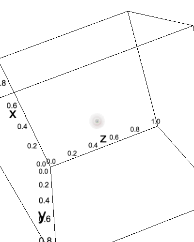

```
2-0-0
```

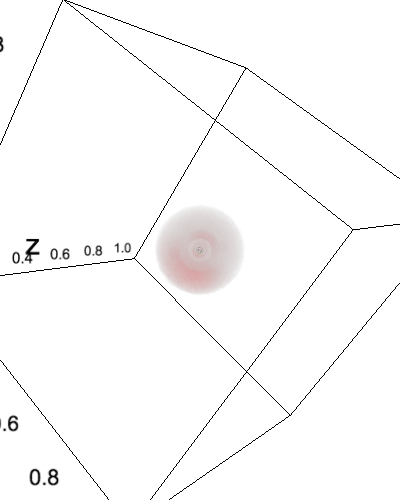

```
2-1-0
```

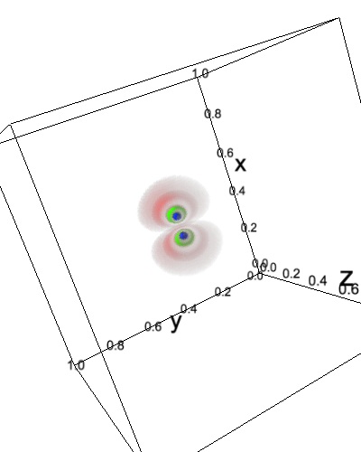

```
2-1-1
```

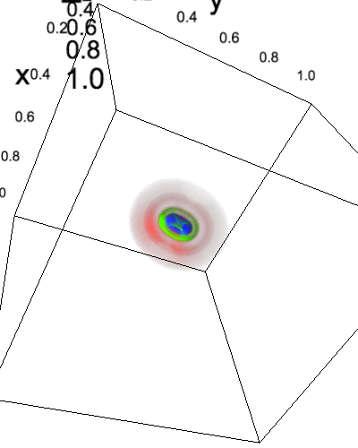

```
3-0-0
```

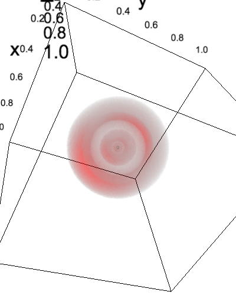

```
3-1-0
```

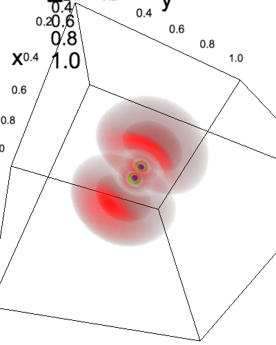

```
3-1-1
```

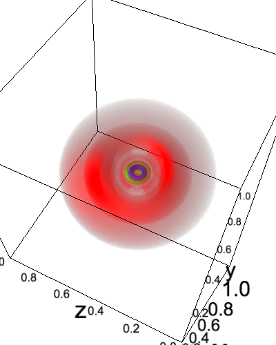

```
3-2-0
```

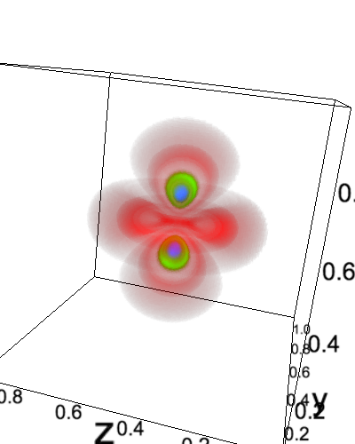

```
3-2-1
```

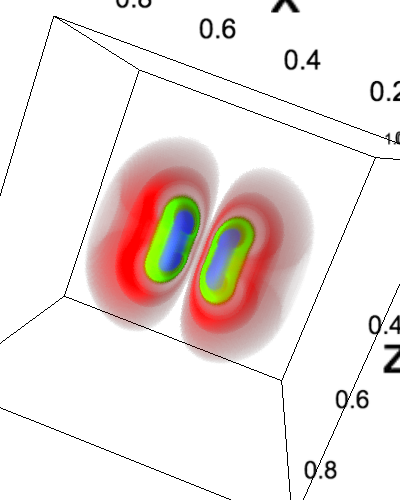

```
3-2-2
```

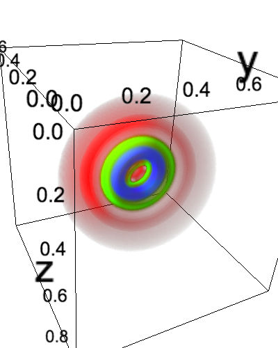

```python
from IPython.display import Image
for i in names:
    print(i)
    display(Image(filename = i+'.png'))
```

# Вычисления в ORCA

Теперь посмотрим, что нам выдаст программа ORCA. Возьмем результаты ее работы на кластере. Код на bash:

ssh -p 22025 shad@vsb.fbb.msu.ru # password: shad123

cd ./hse

mkdir sakharova

cp -r /home/shad/progs/bin/orca ./sakharova

orca h.inp

scp -r -P 22025 shad@vsb.fbb.msu.ru:/home/shad/hse/sakharova/*.cube /Users/Ekaterina/orca

```python
%%writefile h.in
! UHF SVP XYZFile
%plots Format Cube
 MO("H-0.cube",0,0);
 MO("H-1.cube",1,0);
 MO("H-2.cube",2,0);
 MO("H-3.cube",3,0);
 MO("H-4.cube",4,0);
 MO("H-5.cube",4,0);
 MO("H-6.cube",4,0);
 MO("H-7.cube",4,0);
 MO("H-8.cube",4,0);
 MO("H-9.cube",4,0);
end
* xyz 0 4
 H 0 0 0
*
```

```
Overwriting h.in
```

Тут уж получились .cube файлы. Нарисуем их с помощью PyMol.

```python
import pymol
from pymol import cmd
import time
from IPython.display import Image
from threading import Thread
pymol.finish_launching()
```

Сделаем файл для команд PyMol. Установим отрисовку volumeи что откуда открывать. Загрузим в PyMol, сохраним картинки и сразу же выведем их в Notebook.

```python
for i in range(1,11):
    f = open ('orca_result.pml', 'w')
    f.write('cmd.volume_ramp_new(\'ramp008\', [\
          0.0002,  1.00, 0.00, 0.00, 0.0005, \
          0.0010,  1.00, 1.00, 0.00, 0.005, \
          0.0025,  0.00, 1.00, 0.00, 0.01, \
          0.005,   0.00, 1.00, 1.00, 0.02, \
          0.01,    0.00, 0.00, 1.00, 0.01, \
          0.015,   1.00, 0.00, 1.00, 0.005, \
        ])\n')
    name = "H-"+'%s' % (i)
    full_name = name + '.cube'
    vol_name = name+'_v'
    f.write('load ~/orca/2/%s, %s\n' % (full_name, name))
    f.write('volume %s, %s\n' % (vol_name, name))
    f.write('volume_color %s, ramp008\n' % (vol_name))

    cmd.do('load ~/orca_result.pml')
    cmd.do('png ~/orca/2/'+str(i)+'.png')
    cmd.do('delete all')
```

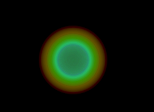

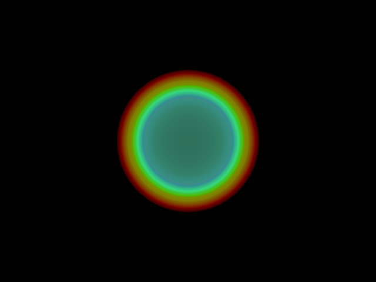

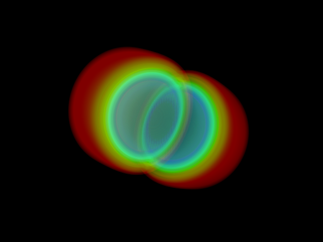

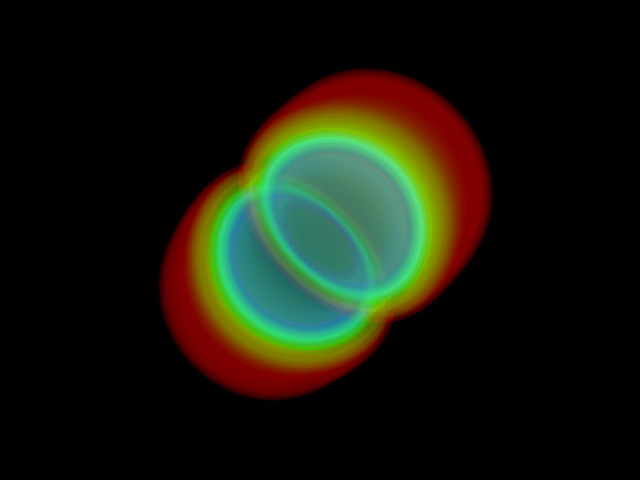

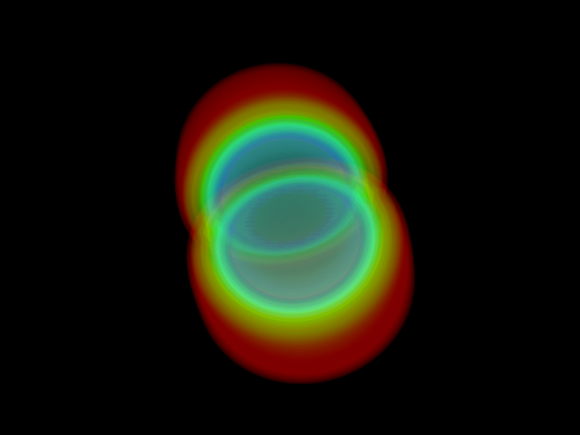

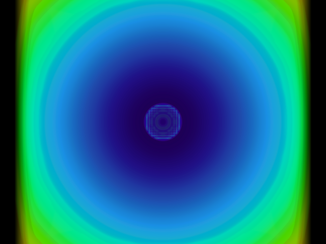

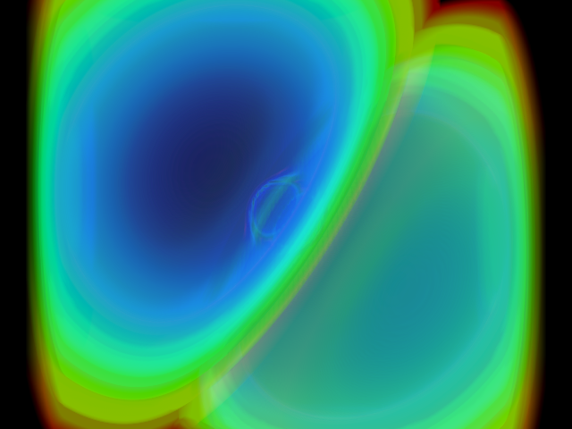

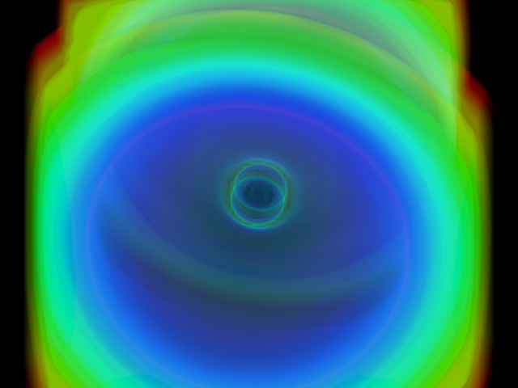

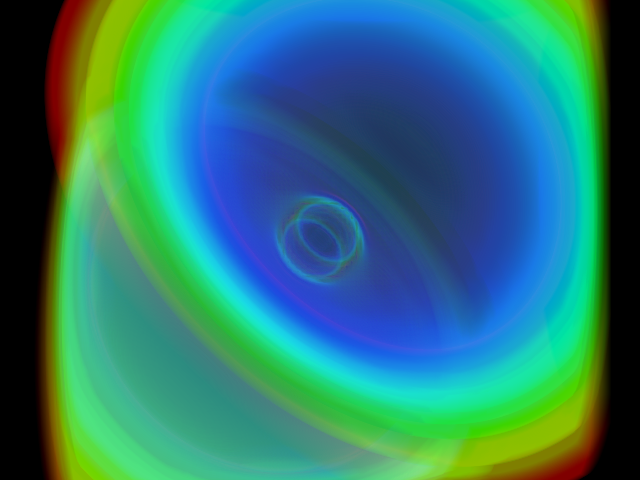

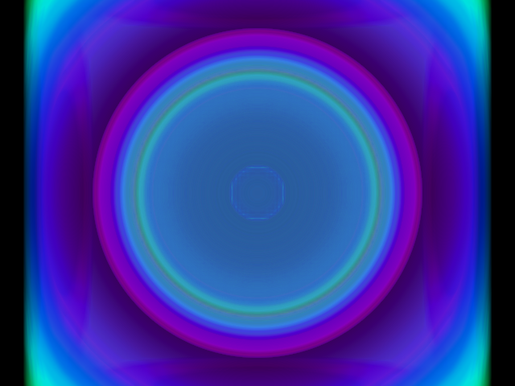

```python
for i in range(1,11):
    display(Image(filename = 'orca/2/'+str(i)+'.png', width=400, height=400))
```

Тоже ничего так получилось. Вроде похожесть можно найти :)